# Transparency indicators across the dentistry and oral health literature - Analysis

Eero Raittio, Ahmad Sofi-Mahmudi, Sergio E Uribe

# Loading required packages

```r
pacman::p_load(dplyr,
               ggplot2,
               knitr,
               here,
               tidyr,
               europepmc,
               lubridate,
               ggpubr,
               epiR,
               gtsummary,
               forcats,
               nortest,
               caret,
               tibble,
               ggrepel)
```

# Loading the datasets

First, set working directory to the folder that has all the datasets in it using setwd() function and then run the following code:

```r
opendata <- read.csv(here("data", "dental_transparency_opendata.csv"))
```

Adding and cleaning publisher and journal related information (journal impact factor) to the dataset:

```r
jif <- read.csv(here("data", "dental_transparency_journals.csv"))
jif$scimago_publisher = ifelse( jif$scimago_publisher == "Elsevier Inc." | jif$scimago_publisher == "Elsevier BV"  |   jif$scimago_publisher == "Elsevier Ltd."| jif$scimago_publisher == "Elsevier USA" | jif$scimago_publisher == "Elsevier Science",  "Elsevier", ifelse(jif$scimago_publisher == "BioMed Central Ltd." | jif$scimago_publisher == "Springer Japan" |  jif$scimago_publisher == "Springer Verlag",   "Nature Publishing Group", ifelse(jif$scimago_publisher == "Sage Publications"  | jif$scimago_publisher == "SAGE Publications Ltd","SAGE Publications Inc.", ifelse(jif$scimago_publisher ==  "Wiley-Blackwell Publishing Ltd"  |jif$scimago_publisher ==  "Wiley-Blackwell"  | jif$scimago_publisher ==  "Blackwell Munksgaard","John Wiley & Sons Inc.",jif$scimago_publisher ))))

opendata <- merge(x = opendata, y = jif[, c("abbreviation", "jif2020","scimago_publisher")], by.x = "journalTitle",by.y = "abbreviation",all.x = TRUE)
```

Data including non-OA articles

```r
db_all <- read.csv(here("data", "dental_transparency_db.csv"))

alldata <- merge(x = db_all,
                  y = jif[, c("abbreviation", "jif2020","scimago_publisher")],
                  by.x = "journalTitle",
                  by.y = "abbreviation",
                  all.x = TRUE)
```

# Results

Number of all papers (open access and non open access), open-access papers and open-access percentage:

```r
kable(data.frame(hits_all = 329784,
           hits_oa = nrow(opendata),
           oa_percentage = round((nrow(opendata)/329784)*100, 1)))
```

| hits_all | hits_oa | oa_percentage |
| --- | --- | --- |
| 329784 | 10659 | 3.2 |

First, adding the real publication year and month to the datasets. The real publication year/month is the year/month the paper was first appear online stored in firstPublicationDate column.

```r
opendata <- opendata %>%
  mutate(year_firstpub = year(
    as.POSIXlt(firstPublicationDate,
               format = "%Y-%m-%d")),
    month_firstpub = month(
      as.POSIXlt(firstPublicationDate,
               format = "%Y-%m-%d")
    )
    )

opendata <- opendata %>%
        mutate(pubYear_modified =
                       ifelse(year_firstpub < 2000, "<2000",
                     ifelse((year_firstpub >= 2000) & (year_firstpub < 2005), "2000-2004",
                     ifelse((year_firstpub >= 2005) & (year_firstpub < 2010), "2005-2009",
                     year_firstpub))))
```

Number of open access papers per year:

```r
opendata %>% select(pubYear_modified) %>% tbl_summary()
```

| **Characteristic** | **N = 10,659**<sup>1</sup> |
| --- | --- |
| pubYear_modified |  |
| <2000 | 3 (<0.1%) |
| 2000-2004 | 24 (0.2%) |
| 2005-2009 | 738 (6.9%) |
| 2010 | 208 (2.0%) |
| 2011 | 231 (2.2%) |
| 2012 | 464 (4.4%) |
| 2013 | 486 (4.6%) |
| 2014 | 616 (5.8%) |
| 2015 | 727 (6.8%) |
| 2016 | 743 (7.0%) |
| 2017 | 726 (6.8%) |
| 2018 | 1,070 (10%) |
| 2019 | 1,004 (9.4%) |
| 2020 | 1,747 (16%) |
| 2021 | 1,872 (18%) |

<sup>1</sup> n (%)

The number of journals in our dataset:

```r
length(table(opendata$journalTitle))
```

```
## [1] 78
```

```r
head(table(opendata$journalTitle) %>% as.data.frame() %>% arrange(desc(Freq)), 5)
```

```
##                            Var1 Freq
## 1               BMC Oral Health 2503
## 2               J Appl Oral Sci 1440
## 3 Med Oral Patol Oral Cir Bucal 1174
## 4                 Head Face Med  572
## 5         Dental Press J Orthod  530
```

The mean and the median of the number of citations to these references:

```r
kable(data.frame(Mean = round(mean(opendata$citedByCount),1),
           SD = round(sd(opendata$citedByCount), 1),
           Median = median(opendata$citedByCount),
           IQR = IQR(opendata$citedByCount)
           ))
```

| Mean | SD | Median | IQR |
| --- | --- | --- | --- |
| 5.7 | 15 | 2 | 7 |

Characteristics of the paper with the highest number of citations:

```r
kable(opendata[which.max(opendata$citedByCount),] %>%
  select(citedByCount, pmid,title, authorString, journalTitle, firstPublicationDate))
```

|  | citedByCount | pmid | title | authorString | journalTitle | firstPublicationDate |
| --- | --- | --- | --- | --- | --- | --- |
| 5750 | 812 | 32094336 | High expression of ACE2 receptor of 2019-nCoV on the epithelial cells of oral mucosa. | Xu H, Zhong L, Deng J, Peng J, Dan H, Zeng X, Li T, Chen Q. | Int J Oral Sci | 2020-02-24 |

The number and percentage of papers with a conflict of interest (COI) disclosure:

```r
kable(data.frame(
  number = length(opendata$is_coi_pred[opendata$is_coi_pred == TRUE]),
           percentage = round(length(opendata$is_coi_pred[opendata$is_coi_pred == TRUE])/nrow(opendata)*100, 1)
           ))
```

| number | percentage |
| --- | --- |
| 8173 | 76.7 |

Confidence interval for COI:

```r
kable(round(epi.prev(pos = length(opendata$is_coi_pred[opendata$is_coi_pred == TRUE]),
         tested = nrow(opendata),
         se = 0.992,
         sp = 0.995)$ap,
      1))
```

| est | lower | upper |
| --- | --- | --- |
| 76.7 | 75.9 | 77.5 |

The number and percentage of papers with a funding disclosure:

```r
kable(data.frame(number = length(opendata$is_fund_pred[opendata$is_fund_pred == TRUE]),
           percentage = round(length(opendata$is_fund_pred[opendata$is_fund_pred == TRUE])/nrow(opendata)*100, 1)
           ))
```

| number | percentage |
| --- | --- |
| 6558 | 61.5 |

Confidence interval for funding disclosure:

```r
kable(round(epi.prev(pos = length(opendata$is_fund_pred[opendata$is_fund_pred == TRUE]),
         tested = nrow(opendata),
         se = 0.997,
         sp = 0.981)$ap,
      1))
```

| est | lower | upper |
| --- | --- | --- |
| 61.5 | 60.6 | 62.4 |

The number and percentage of protocol registration:

```r
kable(data.frame(number = length(opendata$is_register_pred[opendata$is_register_pred == TRUE]),
           percentage = round(length(opendata$is_register_pred[opendata$is_register_pred == TRUE])/nrow(opendata)*100, 1)
           ))
```

| number | percentage |
| --- | --- |
| 737 | 6.9 |

Confidence interval for protocol registration:

```r
kable(round(epi.prev(pos = length(opendata$is_register_pred[opendata$is_register_pred == TRUE]),
         tested = nrow(opendata),
         se = 0.955,
         sp = 0.997)$ap,
      1))
```

| est | lower | upper |
| --- | --- | --- |
| 6.9 | 6.4 | 7.4 |

The number and percentage of papers that shared data:

```r
kable(data.frame(number = length(opendata$is_open_data[opendata$is_open_data == TRUE]),
           percentage = round(length(opendata$is_open_data[opendata$is_open_data == TRUE])/nrow(opendata)*100, 1)
           ))
```

| number | percentage |
| --- | --- |
| 212 | 2 |

Confidence interval for data sharing:

```r
kable(round(epi.prev(pos = length(opendata$is_open_data[opendata$is_open_data == TRUE]),
         tested = nrow(opendata),
         se = 0.758,
         sp = 0.986)$ap,
      1))
```

| est | lower | upper |
| --- | --- | --- |
| 2 | 1.7 | 2.3 |

The number and percentage of papers that shared code:

```r
kable(data.frame(number = length(opendata$is_open_code[opendata$is_open_code == TRUE]),
           percentage = round(length(opendata$is_open_code[opendata$is_open_code == TRUE])/nrow(opendata)*100, 1)
           ))
```

| number | percentage |
| --- | --- |
| 8 | 0.1 |

Confidence interval for sharing code:

```r
kable(round(epi.prev(pos = length(opendata$is_open_code[opendata$is_open_code == TRUE]),
         tested = nrow(opendata),
         se = 0.587,
         sp = 0.997)$ap,
      1))
```

| est | lower | upper |
| --- | --- | --- |
| 0.1 | 0 | 0.1 |

Sum of five indicators:

```r
opendata %>% mutate(sum = rowSums(opendata %>% select(is_coi_pred, is_register_pred, is_fund_pred, is_open_data, is_open_code))) %>% select(sum) %>% tbl_summary()
```

| **Characteristic** | **N = 10,659**<sup>1</sup> |
| --- | --- |
| sum |  |
| 0 | 1,697 (16%) |
| 1 | 3,048 (29%) |
| 2 | 5,134 (48%) |
| 3 | 748 (7.0%) |
| 4 | 32 (0.3%) |

<sup>1</sup> n (%)

## Journal-related differences in transparency (Table 1)

Five highest impact journals

```r
tapply(opendata$jif2020.x, opendata$journalTitle, max) %>% as.data.frame() %>% arrange(desc(.)) %>% head(5)
```

```
##                        .
## J Clin Periodontol 8.728
## Periodontol 2000   7.589
## J Periodontol      6.993
## Int J Oral Sci     6.344
## J Dent Res         6.116
```

```r
opendata$jif2020c = ifelse(opendata$jif2020.x < 6.116,"Other",opendata$journalTitle)
```

Table

```r
set.seed(100)
opendata %>%
  select(jif2020c,is_coi_pred,is_fund_pred,is_register_pred,is_open_data,is_open_code) %>%
  tbl_summary(by=jif2020c, percent="column",
              label = c(is_coi_pred ~ "COI disclosure", is_fund_pred ~ "Funding disclosure", is_register_pred ~ "Protocol registration", is_open_data ~ "Data sharing", is_open_code ~ "Code sharing")) %>%
  add_p(test.args=all_tests("fisher.test") ~ list(simulate.p.value=TRUE)) %>%
        as_flex_table()
```

| Characteristic | Int J Oral Sci, N = 4471 | J Clin Periodontol, N = 791 | J Dent Res, N = 731 | J Periodontol, N = 201 | Other, N = 8,0811 | Periodontol 2000, N = 301 | p-value2 |
| --- | --- | --- | --- | --- | --- | --- | --- |
| COI disclosure | 157 (35%) | 73 (92%) | 73 (100%) | 18 (90%) | 6,265 (78%) | 4 (13%) | <0.001 |
| Funding disclosure | 296 (66%) | 70 (89%) | 73 (100%) | 17 (85%) | 5,131 (63%) | 17 (57%) | <0.001 |
| Protocol registration | 1 (0.2%) | 21 (27%) | 3 (4.1%) | 3 (15%) | 636 (7.9%) | 0 (0%) | <0.001 |
| Data sharing | 8 (1.8%) | 5 (6.3%) | 3 (4.1%) | 0 (0%) | 171 (2.1%) | 1 (3.3%) | 0.11 |
| Code sharing | 0 (0%) | 0 (0%) | 0 (0%) | 0 (0%) | 8 (<0.1%) | 0 (0%) | >0.9 |

1n (%)  
2Fisher's Exact Test for Count Data with simulated p-value (based on 2000 replicates); Pearson's Chi-squared test

Table

```r
set.seed(100)
opendata %>%
  select(journalTitle,is_coi_pred,is_fund_pred,is_register_pred,is_open_data,is_open_code) %>%
        mutate(journalTitle = fct_lump(journalTitle,n=5)) %>%
  tbl_summary(by=journalTitle, percent="column",
              label = c(is_coi_pred ~ "COI disclosure", is_fund_pred ~ "Funding disclosure", is_register_pred ~ "Protocol registration", is_open_data ~ "Data sharing", is_open_code ~ "Code sharing")) %>%
  add_p(test.args=all_tests("fisher.test") ~ list(simulate.p.value=TRUE)) %>%
        as_flex_table()
```

| Characteristic | BMC Oral Health, N = 2,5031 | Dental Press J Orthod, N = 5301 | Head Face Med, N = 5721 | J Appl Oral Sci, N = 1,4401 | Med Oral Patol Oral Cir Bucal, N = 1,1741 | Other, N = 4,4401 | p-value2 |
| --- | --- | --- | --- | --- | --- | --- | --- |
| COI disclosure | 2,489 (99%) | 502 (95%) | 537 (94%) | 303 (21%) | 869 (74%) | 3,473 (78%) | <0.001 |
| Funding disclosure | 2,232 (89%) | 87 (16%) | 280 (49%) | 656 (46%) | 497 (42%) | 2,806 (63%) | <0.001 |
| Protocol registration | 326 (13%) | 12 (2.3%) | 23 (4.0%) | 31 (2.2%) | 43 (3.7%) | 302 (6.8%) | <0.001 |
| Data sharing | 120 (4.8%) | 2 (0.4%) | 2 (0.3%) | 7 (0.5%) | 5 (0.4%) | 76 (1.7%) | <0.001 |
| Code sharing | 6 (0.2%) | 0 (0%) | 0 (0%) | 0 (0%) | 0 (0%) | 2 (<0.1%) | 0.11 |

1n (%)  
2Pearson's Chi-squared test; Fisher's Exact Test for Count Data with simulated p-value (based on 2000 replicates)

Code sharing for all journals and correct p-value for the table

```r
set.seed(100)
opendata %>%
  select(journalTitle,is_open_code) %>%
  tbl_summary(by=journalTitle, percent="row", sort = list(everything() ~ "frequency"))%>%
  add_p(test.args=all_tests("fisher.test") ~ list(simulate.p.value=TRUE)) %>%
        as_flex_table()
```

| Characteristic | Acta Odontol Scand, N = 71 | Am J Orthod Dentofacial Orthop, N = 151 | Anesth Prog, N = 11 | Arch Oral Biol, N = 101 | Aust Dent J, N = 51 | Aust Endod J, N = 21 | BMC Oral Health, N = 2,5031 | Br Dent J, N = 1801 | Br J Oral Maxillofac Surg, N = 611 | Can Med Educ J, N = 11 | Caries Res, N = 41 | Cleft Palate Craniofac J, N = 241 | Clin Exp Dent Res, N = 3991 | Clin Implant Dent Relat Res, N = 341 | Clin Oral Implants Res, N = 531 | Clin Oral Investig, N = 4251 | Community Dent Oral Epidemiol, N = 281 | Dent Clin North Am, N = 11 | Dent Mater, N = 81 | Dent Traumatol, N = 61 | Dental Press J Orthod, N = 5301 | Dentomaxillofac Radiol, N = 111 | Endod Dent Traumatol, N = 11 | Eur Arch Paediatr Dent, N = 571 | Eur Endod J, N = 1481 | Eur J Dent Educ, N = 301 | Eur J Oral Sci, N = 351 | Eur J Orthod, N = 261 | Evid Based Dent, N = 421 | … |
| --- | --- | --- | --- | --- | --- | --- | --- | --- | --- | --- | --- | --- | --- | --- | --- | --- | --- | --- | --- | --- | --- | --- | --- | --- | --- | --- | --- | --- | --- | --- |
| is_open_code | 0 (0%) | 0 (0%) | 0 (0%) | 0 (0%) | 0 (0%) | 0 (0%) | 6 (75%) | 0 (0%) | 0 (0%) | 0 (0%) | 0 (0%) | 0 (0%) | 0 (0%) | 0 (0%) | 0 (0%) | 0 (0%) | 0 (0%) | 0 (0%) | 0 (0%) | 0 (0%) | 0 (0%) | 0 (0%) | 0 (0%) | 0 (0%) | 0 (0%) | 0 (0%) | 0 (0%) | 0 (0%) | 0 (0%) | … |

1n (%)  
2Fisher's Exact Test for Count Data with simulated p-value (based on 2000 replicates)

Data sharing for all journals and correct p-value for the table

```r
set.seed(100)
opendata %>%
  select(journalTitle,is_open_data) %>%
  tbl_summary(by=journalTitle, percent="row", sort = list(everything() ~ "frequency"))%>%
  add_p(test.args=all_tests("fisher.test") ~ list(simulate.p.value=TRUE))%>%
        as_flex_table()
```

| Characteristic | Acta Odontol Scand, N = 71 | Am J Orthod Dentofacial Orthop, N = 151 | Anesth Prog, N = 11 | Arch Oral Biol, N = 101 | Aust Dent J, N = 51 | Aust Endod J, N = 21 | BMC Oral Health, N = 2,5031 | Br Dent J, N = 1801 | Br J Oral Maxillofac Surg, N = 611 | Can Med Educ J, N = 11 | Caries Res, N = 41 | Cleft Palate Craniofac J, N = 241 | Clin Exp Dent Res, N = 3991 | Clin Implant Dent Relat Res, N = 341 | Clin Oral Implants Res, N = 531 | Clin Oral Investig, N = 4251 | Community Dent Oral Epidemiol, N = 281 | Dent Clin North Am, N = 11 | Dent Mater, N = 81 | Dent Traumatol, N = 61 | Dental Press J Orthod, N = 5301 | Dentomaxillofac Radiol, N = 111 | Endod Dent Traumatol, N = 11 | Eur Arch Paediatr Dent, N = 571 | Eur Endod J, N = 1481 | Eur J Dent Educ, N = 301 | Eur J Oral Sci, N = 351 | Eur J Orthod, N = 261 | Evid Based Dent, N = 421 | … |
| --- | --- | --- | --- | --- | --- | --- | --- | --- | --- | --- | --- | --- | --- | --- | --- | --- | --- | --- | --- | --- | --- | --- | --- | --- | --- | --- | --- | --- | --- | --- |
| is_open_data | 0 (0%) | 0 (0%) | 0 (0%) | 0 (0%) | 0 (0%) | 0 (0%) | 120 (57%) | 0 (0%) | 0 (0%) | 0 (0%) | 0 (0%) | 0 (0%) | 21 (9.9%) | 0 (0%) | 1 (0.5%) | 3 (1.4%) | 0 (0%) | 0 (0%) | 0 (0%) | 0 (0%) | 2 (0.9%) | 0 (0%) | 0 (0%) | 1 (0.5%) | 0 (0%) | 0 (0%) | 1 (0.5%) | 1 (0.5%) | 0 (0%) | … |

1n (%)  
2Fisher's Exact Test for Count Data with simulated p-value (based on 2000 replicates)

Protocol registration for all journals and correct p-value for the table

```r
set.seed(100)
opendata %>%
  select(journalTitle,is_register_pred) %>%
  tbl_summary(by=journalTitle, percent="row", sort = list(everything() ~ "frequency"))%>%
  add_p(test.args=all_tests("fisher.test") ~ list(simulate.p.value=TRUE)) %>%
        as_flex_table()
```

| Characteristic | Acta Odontol Scand, N = 71 | Am J Orthod Dentofacial Orthop, N = 151 | Anesth Prog, N = 11 | Arch Oral Biol, N = 101 | Aust Dent J, N = 51 | Aust Endod J, N = 21 | BMC Oral Health, N = 2,5031 | Br Dent J, N = 1801 | Br J Oral Maxillofac Surg, N = 611 | Can Med Educ J, N = 11 | Caries Res, N = 41 | Cleft Palate Craniofac J, N = 241 | Clin Exp Dent Res, N = 3991 | Clin Implant Dent Relat Res, N = 341 | Clin Oral Implants Res, N = 531 | Clin Oral Investig, N = 4251 | Community Dent Oral Epidemiol, N = 281 | Dent Clin North Am, N = 11 | Dent Mater, N = 81 | Dent Traumatol, N = 61 | Dental Press J Orthod, N = 5301 | Dentomaxillofac Radiol, N = 111 | Endod Dent Traumatol, N = 11 | Eur Arch Paediatr Dent, N = 571 | Eur Endod J, N = 1481 | Eur J Dent Educ, N = 301 | Eur J Oral Sci, N = 351 | Eur J Orthod, N = 261 | Evid Based Dent, N = 421 | … |
| --- | --- | --- | --- | --- | --- | --- | --- | --- | --- | --- | --- | --- | --- | --- | --- | --- | --- | --- | --- | --- | --- | --- | --- | --- | --- | --- | --- | --- | --- | --- |
| is_register_pred | 0 (0%) | 0 (0%) | 0 (0%) | 0 (0%) | 1 (0.1%) | 0 (0%) | 326 (44%) | 3 (0.4%) | 3 (0.4%) | 0 (0%) | 0 (0%) | 0 (0%) | 31 (4.2%) | 9 (1.2%) | 8 (1.1%) | 67 (9.1%) | 1 (0.1%) | 0 (0%) | 0 (0%) | 0 (0%) | 12 (1.6%) | 1 (0.1%) | 0 (0%) | 3 (0.4%) | 9 (1.2%) | 0 (0%) | 3 (0.4%) | 6 (0.8%) | 0 (0%) | … |

1n (%)  
2Fisher's Exact Test for Count Data with simulated p-value (based on 2000 replicates)

COI disclosure for all journals and correct p-value for the table

```r
set.seed(100)
opendata %>%
  select(journalTitle,is_coi_pred) %>%
  tbl_summary(by=journalTitle, percent="row", sort = list(everything() ~ "frequency"))%>%
  add_p(test.args=all_tests("fisher.test") ~ list(simulate.p.value=TRUE))%>%
        as_flex_table()
```

| Characteristic | Acta Odontol Scand, N = 71 | Am J Orthod Dentofacial Orthop, N = 151 | Anesth Prog, N = 11 | Arch Oral Biol, N = 101 | Aust Dent J, N = 51 | Aust Endod J, N = 21 | BMC Oral Health, N = 2,5031 | Br Dent J, N = 1801 | Br J Oral Maxillofac Surg, N = 611 | Can Med Educ J, N = 11 | Caries Res, N = 41 | Cleft Palate Craniofac J, N = 241 | Clin Exp Dent Res, N = 3991 | Clin Implant Dent Relat Res, N = 341 | Clin Oral Implants Res, N = 531 | Clin Oral Investig, N = 4251 | Community Dent Oral Epidemiol, N = 281 | Dent Clin North Am, N = 11 | Dent Mater, N = 81 | Dent Traumatol, N = 61 | Dental Press J Orthod, N = 5301 | Dentomaxillofac Radiol, N = 111 | Endod Dent Traumatol, N = 11 | Eur Arch Paediatr Dent, N = 571 | Eur Endod J, N = 1481 | Eur J Dent Educ, N = 301 | Eur J Oral Sci, N = 351 | Eur J Orthod, N = 261 | Evid Based Dent, N = 421 | … |
| --- | --- | --- | --- | --- | --- | --- | --- | --- | --- | --- | --- | --- | --- | --- | --- | --- | --- | --- | --- | --- | --- | --- | --- | --- | --- | --- | --- | --- | --- | --- |
| is_coi_pred | 7 (<0.1%) | 14 (0.2%) | 0 (0%) | 7 (<0.1%) | 5 (<0.1%) | 2 (<0.1%) | 2,489 (30%) | 102 (1.2%) | 59 (0.7%) | 1 (<0.1%) | 3 (<0.1%) | 24 (0.3%) | 345 (4.2%) | 31 (0.4%) | 39 (0.5%) | 410 (5.0%) | 19 (0.2%) | 1 (<0.1%) | 3 (<0.1%) | 3 (<0.1%) | 502 (6.1%) | 2 (<0.1%) | 0 (0%) | 50 (0.6%) | 148 (1.8%) | 18 (0.2%) | 33 (0.4%) | 20 (0.2%) | 1 (<0.1%) | … |

1n (%)  
2Fisher's Exact Test for Count Data with simulated p-value (based on 2000 replicates)

Funding disclosure for all journals and correct p-value for the table

```r
set.seed(100)
opendata %>%
  select(journalTitle,is_fund_pred) %>%
  tbl_summary(by=journalTitle, percent="row", sort = list(everything() ~ "frequency"))%>%
  add_p(test.args=all_tests("fisher.test") ~ list(simulate.p.value=TRUE))%>%
        as_flex_table()
```

| Characteristic | Acta Odontol Scand, N = 71 | Am J Orthod Dentofacial Orthop, N = 151 | Anesth Prog, N = 11 | Arch Oral Biol, N = 101 | Aust Dent J, N = 51 | Aust Endod J, N = 21 | BMC Oral Health, N = 2,5031 | Br Dent J, N = 1801 | Br J Oral Maxillofac Surg, N = 611 | Can Med Educ J, N = 11 | Caries Res, N = 41 | Cleft Palate Craniofac J, N = 241 | Clin Exp Dent Res, N = 3991 | Clin Implant Dent Relat Res, N = 341 | Clin Oral Implants Res, N = 531 | Clin Oral Investig, N = 4251 | Community Dent Oral Epidemiol, N = 281 | Dent Clin North Am, N = 11 | Dent Mater, N = 81 | Dent Traumatol, N = 61 | Dental Press J Orthod, N = 5301 | Dentomaxillofac Radiol, N = 111 | Endod Dent Traumatol, N = 11 | Eur Arch Paediatr Dent, N = 571 | Eur Endod J, N = 1481 | Eur J Dent Educ, N = 301 | Eur J Oral Sci, N = 351 | Eur J Orthod, N = 261 | Evid Based Dent, N = 421 | … |
| --- | --- | --- | --- | --- | --- | --- | --- | --- | --- | --- | --- | --- | --- | --- | --- | --- | --- | --- | --- | --- | --- | --- | --- | --- | --- | --- | --- | --- | --- | --- |
| is_fund_pred | 5 (<0.1%) | 6 (<0.1%) | 1 (<0.1%) | 10 (0.2%) | 5 (<0.1%) | 0 (0%) | 2,232 (34%) | 49 (0.7%) | 8 (0.1%) | 0 (0%) | 4 (<0.1%) | 24 (0.4%) | 258 (3.9%) | 24 (0.4%) | 41 (0.6%) | 334 (5.1%) | 21 (0.3%) | 0 (0%) | 7 (0.1%) | 2 (<0.1%) | 87 (1.3%) | 5 (<0.1%) | 0 (0%) | 37 (0.6%) | 143 (2.2%) | 9 (0.1%) | 24 (0.4%) | 20 (0.3%) | 0 (0%) | … |

1n (%)  
2Fisher's Exact Test for Count Data with simulated p-value (based on 2000 replicates)

Open access rates and cleaning publisher data

```r
alldata %>%
        select(journalTitle,isOpenAccess) %>%
        tbl_summary(by=journalTitle, percent="column", sort = list(everything() ~ "frequency")) %>%
        add_overall() %>%
        as_flex_table()
```

| Characteristic | Overall, N = 10,6601 | Acta Odontol Scand, N = 71 | Am J Orthod Dentofacial Orthop, N = 151 | Anesth Prog, N = 11 | Arch Oral Biol, N = 101 | Aust Dent J, N = 51 | Aust Endod J, N = 21 | BMC Oral Health, N = 2,5031 | Br Dent J, N = 1801 | Br J Oral Maxillofac Surg, N = 611 | Can Med Educ J, N = 11 | Caries Res, N = 41 | Cleft Palate Craniofac J, N = 241 | Clin Exp Dent Res, N = 3991 | Clin Implant Dent Relat Res, N = 341 | Clin Oral Implants Res, N = 531 | Clin Oral Investig, N = 4251 | Community Dent Oral Epidemiol, N = 281 | Dent Clin North Am, N = 11 | Dent Mater, N = 81 | Dent Traumatol, N = 61 | Dental Press J Orthod, N = 5301 | Dentomaxillofac Radiol, N = 111 | Endod Dent Traumatol, N = 11 | Eur Arch Paediatr Dent, N = 571 | Eur Endod J, N = 1481 | Eur J Dent Educ, N = 301 | Eur J Oral Sci, N = 351 | Eur J Orthod, N = 261 | … |
| --- | --- | --- | --- | --- | --- | --- | --- | --- | --- | --- | --- | --- | --- | --- | --- | --- | --- | --- | --- | --- | --- | --- | --- | --- | --- | --- | --- | --- | --- | --- |
| isOpenAccess |  |  |  |  |  |  |  |  |  |  |  |  |  |  |  |  |  |  |  |  |  |  |  |  |  |  |  |  |  | … |
| Y | 10,660 (100%) | 7 (100%) | 15 (100%) | 1 (100%) | 10 (100%) | 5 (100%) | 2 (100%) | 2,503 (100%) | 180 (100%) | 61 (100%) | 1 (100%) | 4 (100%) | 24 (100%) | 399 (100%) | 34 (100%) | 53 (100%) | 425 (100%) | 28 (100%) | 1 (100%) | 8 (100%) | 6 (100%) | 530 (100%) | 11 (100%) | 1 (100%) | 57 (100%) | 148 (100%) | 30 (100%) | 35 (100%) | 26 (100%) | … |

1n (%)

## Publisher-related differences in transparency (Table 2)

Table

```r
set.seed(100)
opendata %>%
  select(scimago_publisher.y,is_coi_pred,is_fund_pred,is_register_pred,is_open_data,is_open_code) %>%
        mutate(scimago_publisher.y = fct_lump(scimago_publisher.y,n=6)) %>%
  tbl_summary(by=scimago_publisher.y, percent="column",
              label = c(is_coi_pred ~ "COI disclosure", is_fund_pred ~ "Funding disclosure", is_register_pred ~ "Protocol registration", is_open_data ~ "Data sharing", is_open_code ~ "Code sharing")) %>%
  add_p(test.args=all_tests("fisher.test") ~ list(simulate.p.value=TRUE)) %>%
        as_flex_table()
```

| Characteristic | Dental Press Editora Ltda, N = 5301 | Faculdade de Odontologia de Bauru, N = 1,4401 | John Wiley & Sons Inc., N = 1,0641 | Medicina Oral, Patologia Oral y Cirugia Bucal, N = 1,1741 | Nature Publishing Group, N = 4,2741 | Wolters Kluwer Medknow Publications, N = 4951 | Other, N = 1,2911 | p-value2 |
| --- | --- | --- | --- | --- | --- | --- | --- | --- |
| COI disclosure | 502 (95%) | 303 (21%) | 857 (81%) | 869 (74%) | 4,075 (95%) | 301 (61%) | 876 (68%) | <0.001 |
| Funding disclosure | 87 (16%) | 656 (46%) | 701 (66%) | 497 (42%) | 3,187 (75%) | 301 (61%) | 813 (63%) | <0.001 |
| Protocol registration | 12 (2.3%) | 31 (2.2%) | 100 (9.4%) | 43 (3.7%) | 466 (11%) | 4 (0.8%) | 40 (3.1%) | <0.001 |
| Data sharing | 2 (0.4%) | 7 (0.5%) | 37 (3.5%) | 5 (0.4%) | 135 (3.2%) | 0 (0%) | 17 (1.3%) | <0.001 |
| Code sharing | 0 (0%) | 0 (0%) | 1 (<0.1%) | 0 (0%) | 7 (0.2%) | 0 (0%) | 0 (0%) | 0.4 |

1n (%)  
2Pearson's Chi-squared test; Fisher's Exact Test for Count Data with simulated p-value (based on 2000 replicates)

Code sharing for all publishers and correct p-value for the table

```r
set.seed(100)
opendata %>%
select(scimago_publisher.y,is_open_code) %>%
tbl_summary(by=scimago_publisher.y, percent="row", sort = list(everything() ~ "frequency"))%>%
 add_p(test.args=all_tests("fisher.test") ~ list(simulate.p.value=TRUE))%>%
        as_flex_table()
```

| Characteristic | Allen Press Inc., N = 11 | American Cleft Palate Craniofacial Association, N = 241 | American Dental Association, N = 381 | American Dental Education Association, N = 761 | American Journal of Nursing Company, N = 171 | British Institute of Radiology, N = 111 | Churchill Livingstone, N = 721 | Dental Press Editora Ltda, N = 5301 | Elsevier, N = 721 | Faculdade de Odontologia de Bauru, N = 1,4401 | Informa Healthcare, N = 71 | Japanese Association for Oral Biology, N = 11 | John Wiley & Sons Inc., N = 1,0641 | Kare Publishing, N = 1481 | Lippincott Williams and Wilkins Ltd., N = 1171 | Medicina Oral, Patologia Oral y Cirugia Bucal, N = 1,1741 | Mosby Inc., N = 251 | Nature Publishing Group, N = 4,2741 | Oxford University Press, N = 261 | Quintessence Publishing Company, N = 11 | S. Karger AG, N = 41 | SAGE Publications Inc., N = 1251 | Sichuan University Press, N = 4471 | Thieme Medical Publishers Inc., N = 21 | Urban und Vogel, N = 351 | W.B. Saunders Ltd, N = 421 | Wolters Kluwer Medknow Publications, N = 4951 | p-value2 |
| --- | --- | --- | --- | --- | --- | --- | --- | --- | --- | --- | --- | --- | --- | --- | --- | --- | --- | --- | --- | --- | --- | --- | --- | --- | --- | --- | --- | --- |
| is_open_code | 0 (0%) | 0 (0%) | 0 (0%) | 0 (0%) | 0 (0%) | 0 (0%) | 0 (0%) | 0 (0%) | 0 (0%) | 0 (0%) | 0 (0%) | 0 (0%) | 1 (12%) | 0 (0%) | 0 (0%) | 0 (0%) | 0 (0%) | 7 (88%) | 0 (0%) | 0 (0%) | 0 (0%) | 0 (0%) | 0 (0%) | 0 (0%) | 0 (0%) | 0 (0%) | 0 (0%) | 0.8 |

1n (%)  
2Fisher's Exact Test for Count Data with simulated p-value (based on 2000 replicates)

Data sharing for all publishers and correct p-value for the table

```r
set.seed(100)
opendata %>%
select(scimago_publisher.y,is_open_data) %>%
tbl_summary(by=scimago_publisher.y, percent="row", sort = list(everything() ~ "frequency"))%>%
 add_p(test.args=all_tests("fisher.test") ~ list(simulate.p.value=TRUE))%>%
        as_flex_table()
```

| Characteristic | Allen Press Inc., N = 11 | American Cleft Palate Craniofacial Association, N = 241 | American Dental Association, N = 381 | American Dental Education Association, N = 761 | American Journal of Nursing Company, N = 171 | British Institute of Radiology, N = 111 | Churchill Livingstone, N = 721 | Dental Press Editora Ltda, N = 5301 | Elsevier, N = 721 | Faculdade de Odontologia de Bauru, N = 1,4401 | Informa Healthcare, N = 71 | Japanese Association for Oral Biology, N = 11 | John Wiley & Sons Inc., N = 1,0641 | Kare Publishing, N = 1481 | Lippincott Williams and Wilkins Ltd., N = 1171 | Medicina Oral, Patologia Oral y Cirugia Bucal, N = 1,1741 | Mosby Inc., N = 251 | Nature Publishing Group, N = 4,2741 | Oxford University Press, N = 261 | Quintessence Publishing Company, N = 11 | S. Karger AG, N = 41 | SAGE Publications Inc., N = 1251 | Sichuan University Press, N = 4471 | Thieme Medical Publishers Inc., N = 21 | Urban und Vogel, N = 351 | W.B. Saunders Ltd, N = 421 | Wolters Kluwer Medknow Publications, N = 4951 | p-value2 |
| --- | --- | --- | --- | --- | --- | --- | --- | --- | --- | --- | --- | --- | --- | --- | --- | --- | --- | --- | --- | --- | --- | --- | --- | --- | --- | --- | --- | --- |
| is_open_data | 0 (0%) | 0 (0%) | 0 (0%) | 0 (0%) | 3 (1.5%) | 0 (0%) | 0 (0%) | 2 (1.0%) | 1 (0.5%) | 7 (3.4%) | 0 (0%) | 0 (0%) | 37 (18%) | 0 (0%) | 0 (0%) | 5 (2.5%) | 0 (0%) | 135 (67%) | 1 (0.5%) | 0 (0%) | 0 (0%) | 3 (1.5%) | 8 (3.9%) | 0 (0%) | 1 (0.5%) | 0 (0%) | 0 (0%) | <0.001 |

1n (%)  
2Fisher's Exact Test for Count Data with simulated p-value (based on 2000 replicates)

Protocol registeration in all publishers and correct p-value for the table

```r
set.seed(100)
opendata %>%
select(scimago_publisher.y,is_register_pred) %>%
tbl_summary(by=scimago_publisher.y, percent="row", sort = list(everything() ~ "frequency"))%>%
  add_p(test.args=all_tests("fisher.test") ~ list(simulate.p.value=TRUE))%>%
        as_flex_table()
```

| Characteristic | Allen Press Inc., N = 11 | American Cleft Palate Craniofacial Association, N = 241 | American Dental Association, N = 381 | American Dental Education Association, N = 761 | American Journal of Nursing Company, N = 171 | British Institute of Radiology, N = 111 | Churchill Livingstone, N = 721 | Dental Press Editora Ltda, N = 5301 | Elsevier, N = 721 | Faculdade de Odontologia de Bauru, N = 1,4401 | Informa Healthcare, N = 71 | Japanese Association for Oral Biology, N = 11 | John Wiley & Sons Inc., N = 1,0641 | Kare Publishing, N = 1481 | Lippincott Williams and Wilkins Ltd., N = 1171 | Medicina Oral, Patologia Oral y Cirugia Bucal, N = 1,1741 | Mosby Inc., N = 251 | Nature Publishing Group, N = 4,2741 | Oxford University Press, N = 261 | Quintessence Publishing Company, N = 11 | S. Karger AG, N = 41 | SAGE Publications Inc., N = 1251 | Sichuan University Press, N = 4471 | Thieme Medical Publishers Inc., N = 21 | Urban und Vogel, N = 351 | W.B. Saunders Ltd, N = 421 | Wolters Kluwer Medknow Publications, N = 4951 | p-value2 |
| --- | --- | --- | --- | --- | --- | --- | --- | --- | --- | --- | --- | --- | --- | --- | --- | --- | --- | --- | --- | --- | --- | --- | --- | --- | --- | --- | --- | --- |
| is_register_pred | 0 (0%) | 0 (0%) | 3 (0.4%) | 1 (0.1%) | 0 (0%) | 1 (0.1%) | 3 (0.4%) | 12 (1.7%) | 2 (0.3%) | 31 (4.5%) | 0 (0%) | 0 (0%) | 100 (14%) | 9 (1.3%) | 2 (0.3%) | 43 (6.2%) | 1 (0.1%) | 466 (67%) | 6 (0.9%) | 0 (0%) | 0 (0%) | 9 (1.3%) | 1 (0.1%) | 1 (0.1%) | 1 (0.1%) | 0 (0%) | 4 (0.6%) | <0.001 |

1n (%)  
2Fisher's Exact Test for Count Data with simulated p-value (based on 2000 replicates)

COI disclosure in all publishers and correct p-value for the table

```r
set.seed(100)
opendata %>%
select(scimago_publisher.y,is_coi_pred) %>%
tbl_summary(by=scimago_publisher.y, percent="row", sort = list(everything() ~ "frequency")) %>%
  add_p(test.args=all_tests("fisher.test") ~ list(simulate.p.value=TRUE))%>%
        as_flex_table()
```

| Characteristic | Allen Press Inc., N = 11 | American Cleft Palate Craniofacial Association, N = 241 | American Dental Association, N = 381 | American Dental Education Association, N = 761 | American Journal of Nursing Company, N = 171 | British Institute of Radiology, N = 111 | Churchill Livingstone, N = 721 | Dental Press Editora Ltda, N = 5301 | Elsevier, N = 721 | Faculdade de Odontologia de Bauru, N = 1,4401 | Informa Healthcare, N = 71 | Japanese Association for Oral Biology, N = 11 | John Wiley & Sons Inc., N = 1,0641 | Kare Publishing, N = 1481 | Lippincott Williams and Wilkins Ltd., N = 1171 | Medicina Oral, Patologia Oral y Cirugia Bucal, N = 1,1741 | Mosby Inc., N = 251 | Nature Publishing Group, N = 4,2741 | Oxford University Press, N = 261 | Quintessence Publishing Company, N = 11 | S. Karger AG, N = 41 | SAGE Publications Inc., N = 1251 | Sichuan University Press, N = 4471 | Thieme Medical Publishers Inc., N = 21 | Urban und Vogel, N = 351 | W.B. Saunders Ltd, N = 421 | Wolters Kluwer Medknow Publications, N = 4951 | p-value2 |
| --- | --- | --- | --- | --- | --- | --- | --- | --- | --- | --- | --- | --- | --- | --- | --- | --- | --- | --- | --- | --- | --- | --- | --- | --- | --- | --- | --- | --- |
| is_coi_pred | 0 (0%) | 24 (0.3%) | 34 (0.4%) | 16 (0.2%) | 14 (0.2%) | 2 (<0.1%) | 68 (0.9%) | 502 (6.4%) | 51 (0.7%) | 303 (3.9%) | 7 (<0.1%) | 1 (<0.1%) | 857 (11%) | 148 (1.9%) | 114 (1.5%) | 869 (11%) | 17 (0.2%) | 4,075 (52%) | 20 (0.3%) | 1 (<0.1%) | 3 (<0.1%) | 121 (1.6%) | 157 (2.0%) | 2 (<0.1%) | 34 (0.4%) | 42 (0.5%) | 301 (3.9%) | <0.001 |

1n (%)  
2Fisher's Exact Test for Count Data with simulated p-value (based on 2000 replicates)

Funding disclosure in all publishers and correct p-value for the table

```r
set.seed(100)
opendata %>%
select(scimago_publisher.y,is_fund_pred) %>%
tbl_summary(by=scimago_publisher.y, percent="row", sort = list(everything() ~ "frequency")) %>%
add_p(test.args=all_tests("fisher.test") ~ list(simulate.p.value=TRUE))%>%
        as_flex_table()
```

| Characteristic | Allen Press Inc., N = 11 | American Cleft Palate Craniofacial Association, N = 241 | American Dental Association, N = 381 | American Dental Education Association, N = 761 | American Journal of Nursing Company, N = 171 | British Institute of Radiology, N = 111 | Churchill Livingstone, N = 721 | Dental Press Editora Ltda, N = 5301 | Elsevier, N = 721 | Faculdade de Odontologia de Bauru, N = 1,4401 | Informa Healthcare, N = 71 | Japanese Association for Oral Biology, N = 11 | John Wiley & Sons Inc., N = 1,0641 | Kare Publishing, N = 1481 | Lippincott Williams and Wilkins Ltd., N = 1171 | Medicina Oral, Patologia Oral y Cirugia Bucal, N = 1,1741 | Mosby Inc., N = 251 | Nature Publishing Group, N = 4,2741 | Oxford University Press, N = 261 | Quintessence Publishing Company, N = 11 | S. Karger AG, N = 41 | SAGE Publications Inc., N = 1251 | Sichuan University Press, N = 4471 | Thieme Medical Publishers Inc., N = 21 | Urban und Vogel, N = 351 | W.B. Saunders Ltd, N = 421 | Wolters Kluwer Medknow Publications, N = 4951 | p-value2 |
| --- | --- | --- | --- | --- | --- | --- | --- | --- | --- | --- | --- | --- | --- | --- | --- | --- | --- | --- | --- | --- | --- | --- | --- | --- | --- | --- | --- | --- |
| is_fund_pred | 1 (<0.1%) | 24 (0.4%) | 9 (0.1%) | 12 (0.2%) | 17 (0.3%) | 5 (<0.1%) | 17 (0.3%) | 87 (1.4%) | 50 (0.8%) | 656 (11%) | 5 (<0.1%) | 1 (<0.1%) | 701 (11%) | 143 (2.3%) | 35 (0.6%) | 497 (8.0%) | 11 (0.2%) | 3,187 (51%) | 20 (0.3%) | 1 (<0.1%) | 4 (<0.1%) | 122 (2.0%) | 296 (4.7%) | 1 (<0.1%) | 29 (0.5%) | 10 (0.2%) | 301 (4.8%) | <0.001 |

1n (%)  
2Fisher's Exact Test for Count Data with simulated p-value (based on 2000 replicates)

```r
alldata %>%
        select(scimago_publisher,isOpenAccess) %>%
        filter(scimago_publisher ==  "Allen Press Inc."  | scimago_publisher ==  "American Cleft Palate Craniofacial Association" |
 scimago_publisher ==  "American Dental Association" | scimago_publisher ==   "American Dental Education Association"     | scimago_publisher ==   "American Journal of Nursing Company" |scimago_publisher ==    "British Institute of Radiology" | scimago_publisher ==  "Churchill Livingstone" | scimago_publisher ==   "Dental Press Editora Ltda"  | scimago_publisher ==   "Elsevier" | scimago_publisher ==   "Faculdade de Odontologia de Bauru"  | scimago_publisher ==  "Informa Healthcare" |    scimago_publisher ==   "Japanese Association for Oral Biology" | scimago_publisher ==  "John Wiley & Sons Inc."|  scimago_publisher ==    "Kare Publishing" |scimago_publisher ==  "Lippincott Williams and Wilkins Ltd."| scimago_publisher == "Medicina Oral, Patologia Oral y Cirugia Bucal"  |scimago_publisher == "Mosby Inc." |  scimago_publisher ==   "Nature Publishing Group"  |
 scimago_publisher ==  "Oxford University Press"  | scimago_publisher ==  "Quintessence Publishing Company" |scimago_publisher ==  "S. Karger AG" | scimago_publisher ==  "SAGE Publications Inc." | scimago_publisher ==  "Sichuan University Press"| scimago_publisher ==  "Thieme Medical Publishers Inc."| scimago_publisher ==  "Urban und Vogel"| scimago_publisher ==  "W.B. Saunders Ltd"| scimago_publisher ==  "Wolters Kluwer Medknow Publications") %>%
        tbl_summary(by=scimago_publisher, percent="column", sort = list(everything() ~ "frequency")) %>%
        add_overall() %>%
        add_p() %>%
        as_flex_table()
```

| Characteristic | Overall, N = 10,2691 | Allen Press Inc., N = 11 | American Cleft Palate Craniofacial Association, N = 241 | American Dental Association, N = 381 | American Dental Education Association, N = 771 | American Journal of Nursing Company, N = 171 | British Institute of Radiology, N = 111 | Churchill Livingstone, N = 721 | Dental Press Editora Ltda, N = 5301 | Elsevier, N = 721 | Faculdade de Odontologia de Bauru, N = 1,4401 | Informa Healthcare, N = 71 | Japanese Association for Oral Biology, N = 11 | John Wiley & Sons Inc., N = 1,0641 | Kare Publishing, N = 1481 | Lippincott Williams and Wilkins Ltd., N = 1171 | Medicina Oral, Patologia Oral y Cirugia Bucal, N = 1,1741 | Mosby Inc., N = 251 | Nature Publishing Group, N = 4,2741 | Oxford University Press, N = 261 | Quintessence Publishing Company, N = 11 | S. Karger AG, N = 41 | SAGE Publications Inc., N = 1251 | Sichuan University Press, N = 4471 | Thieme Medical Publishers Inc., N = 21 | Urban und Vogel, N = 351 | W.B. Saunders Ltd, N = 421 | Wolters Kluwer Medknow Publications, N = 4951 | p-value |
| --- | --- | --- | --- | --- | --- | --- | --- | --- | --- | --- | --- | --- | --- | --- | --- | --- | --- | --- | --- | --- | --- | --- | --- | --- | --- | --- | --- | --- | --- |
| isOpenAccess |  |  |  |  |  |  |  |  |  |  |  |  |  |  |  |  |  |  |  |  |  |  |  |  |  |  |  |  |  |
| Y | 10,269 (100%) | 1 (100%) | 24 (100%) | 38 (100%) | 77 (100%) | 17 (100%) | 11 (100%) | 72 (100%) | 530 (100%) | 72 (100%) | 1,440 (100%) | 7 (100%) | 1 (100%) | 1,064 (100%) | 148 (100%) | 117 (100%) | 1,174 (100%) | 25 (100%) | 4,274 (100%) | 26 (100%) | 1 (100%) | 4 (100%) | 125 (100%) | 447 (100%) | 2 (100%) | 35 (100%) | 42 (100%) | 495 (100%) |  |

1n (%)

## Journal Impact Factor (JIF) and citation count analyses (Table 3)

Total number of papers published in journals with no JIF:

```r
sum(is.na(opendata$jif2020.x))
```

```
## [1] 1929
```

Normality of JIFs and citations

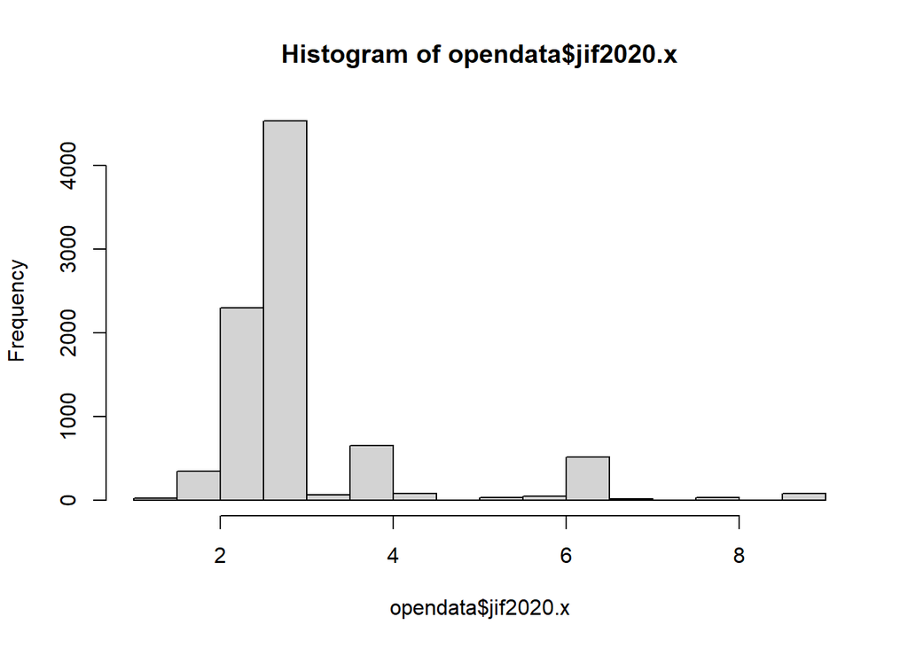

```r
hist(opendata$jif2020.x)
```

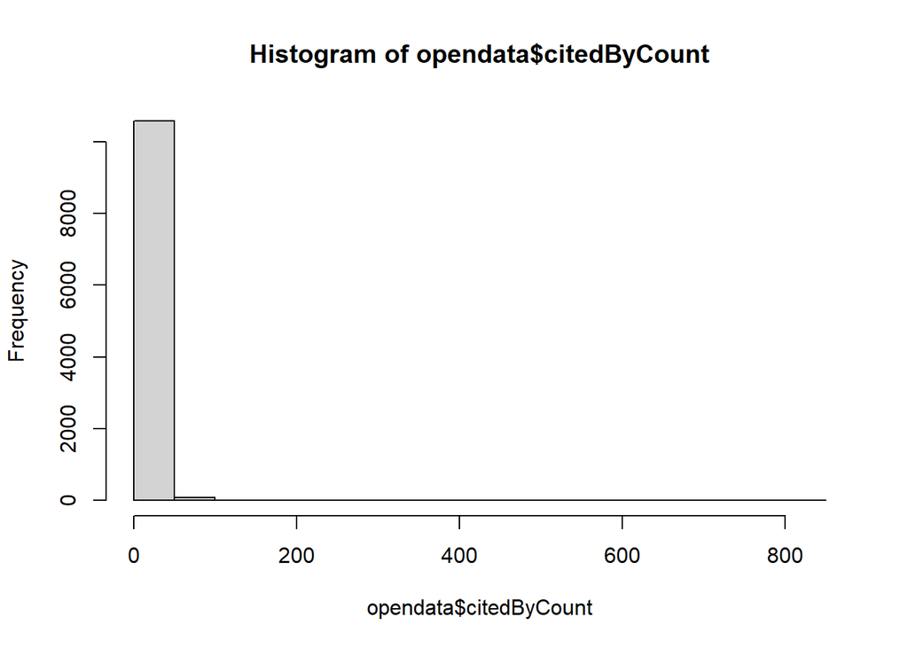

```r
hist(opendata$citedByCount)
```

```r
ad.test(opendata$jif2020.x)
```

```
##
##  Anderson-Darling normality test
##
## data:  opendata$jif2020.x
## A = 1150.4, p-value < 2.2e-16
```

```r
ad.test(opendata$citedByCount)
```

```
##
##  Anderson-Darling normality test
##
## data:  opendata$citedByCount
## A = 1736.2, p-value < 2.2e-16
```

JIF and citations based on COI disclosure:

```r
kable(opendata %>%
  group_by(is_coi_pred) %>%
  summarise(Median = round(median(jif2020.x, na.rm = T), 1),
            IQR = round(IQR(jif2020.x, na.rm = T), 2)))
```

| is_coi_pred | Median | IQR |
| --- | --- | --- |
| FALSE | 2.7 | 0.06 |
| TRUE | 2.8 | 0.61 |

```r
kable(opendata %>%
  group_by(is_coi_pred) %>%
  summarise(Median = round(median(citedByCount, na.rm = T), 1),
            IQR = round(IQR(citedByCount, na.rm = T), 2)))
```

| is_coi_pred | Median | IQR |
| --- | --- | --- |
| FALSE | 5 | 9 |
| TRUE | 2 | 5 |

Data was not normally distributed, hence we will use unpaired two-samples Wilcoxon test.

```r
wilcox.test(jif2020.x~is_coi_pred, data = opendata, exact = FALSE)
```

```
##
##  Wilcoxon rank sum test with continuity correction
##
## data:  jif2020.x by is_coi_pred
## W = 6084935, p-value < 2.2e-16
## alternative hypothesis: true location shift is not equal to 0
```

```r
wilcox.test(citedByCount~is_coi_pred, data = opendata, exact = FALSE)
```

```
##
##  Wilcoxon rank sum test with continuity correction
##
## data:  citedByCount by is_coi_pred
## W = 12956152, p-value < 2.2e-16
## alternative hypothesis: true location shift is not equal to 0
```

JIF and citations based on funding disclosure:

```r
kable(opendata %>%
  group_by(is_fund_pred) %>%
  summarise(Median = round(median(jif2020.x, na.rm = T), 1),
            IQR = round(IQR(jif2020.x, na.rm = T), 2)))
```

| is_fund_pred | Median | IQR |
| --- | --- | --- |
| FALSE | 2.7 | 0.70 |
| TRUE | 2.8 | 0.06 |

```r
kable(opendata %>%
  group_by(is_fund_pred) %>%
  summarise(Median = round(median(citedByCount, na.rm = T), 1),
            IQR = round(IQR(citedByCount, na.rm = T), 2)))
```

| is_fund_pred | Median | IQR |
| --- | --- | --- |
| FALSE | 3 | 7 |
| TRUE | 2 | 5 |

Data was not normally distributed, hence we will use unpaired two-samples Wilcoxon test.

```r
wilcox.test(jif2020.x~is_fund_pred, data = opendata, exact = FALSE)
```

```
##
##  Wilcoxon rank sum test with continuity correction
##
## data:  jif2020.x by is_fund_pred
## W = 5675828, p-value < 2.2e-16
## alternative hypothesis: true location shift is not equal to 0
```

```r
wilcox.test(citedByCount~is_fund_pred, data = opendata, exact = FALSE)
```

```
##
##  Wilcoxon rank sum test with continuity correction
##
## data:  citedByCount by is_fund_pred
## W = 16000916, p-value < 2.2e-16
## alternative hypothesis: true location shift is not equal to 0
```

JIF and citations based on registration:

```r
kable(opendata %>%
  group_by(is_register_pred) %>%
  summarise(Median = round(median(jif2020.x, na.rm = T), 1),
            IQR = round(IQR(jif2020.x, na.rm = T), 2)))
```

| is_register_pred | Median | IQR |
| --- | --- | --- |
| FALSE | 2.7 | 0.61 |
| TRUE | 2.8 | 0.01 |

```r
kable(opendata %>%
  group_by(is_register_pred) %>%
  summarise(Median = round(median(citedByCount, na.rm = T), 1),
            IQR = round(IQR(citedByCount, na.rm = T), 2)))
```

| is_register_pred | Median | IQR |
| --- | --- | --- |
| FALSE | 2 | 7 |
| TRUE | 1 | 4 |

Data was not normally distributed, hence we will use unpaired two-samples Wilcoxon test.

```r
wilcox.test(jif2020.x~is_register_pred, data = opendata, exact = FALSE)
```

```
##
##  Wilcoxon rank sum test with continuity correction
##
## data:  jif2020.x by is_register_pred
## W = 2068742, p-value < 2.2e-16
## alternative hypothesis: true location shift is not equal to 0
```

```r
wilcox.test(citedByCount~is_register_pred, data = opendata, exact = FALSE)
```

```
##
##  Wilcoxon rank sum test with continuity correction
##
## data:  citedByCount by is_register_pred
## W = 4281326, p-value = 4.027e-15
## alternative hypothesis: true location shift is not equal to 0
```

JIF and citations based on data sharing:

```r
kable(opendata %>%
  group_by(is_open_data) %>%
  summarise(Median = round(median(jif2020.x, na.rm = T), 1),
            IQR = round(IQR(jif2020.x, na.rm = T), 2)))
```

| is_open_data | Median | IQR |
| --- | --- | --- |
| FALSE | 2.8 | 0.49 |
| TRUE | 2.8 | 0.00 |

```r
kable(opendata %>%
  group_by(is_open_data) %>%
  summarise(Median = round(median(citedByCount, na.rm = T), 1),
            IQR = round(IQR(citedByCount, na.rm = T), 2)))
```

| is_open_data | Median | IQR |
| --- | --- | --- |
| FALSE | 2 | 7 |
| TRUE | 2 | 4 |

Data was not normally distributed, hence we will use unpaired two-samples Wilcoxon test.

```r
wilcox.test(jif2020.x~is_open_data, data = opendata, exact = FALSE)
```

```
##
##  Wilcoxon rank sum test with continuity correction
##
## data:  jif2020.x by is_open_data
## W = 545473, p-value = 1.966e-14
## alternative hypothesis: true location shift is not equal to 0
```

```r
wilcox.test(citedByCount~is_open_data, data = opendata, exact = FALSE)
```

```
##
##  Wilcoxon rank sum test with continuity correction
##
## data:  citedByCount by is_open_data
## W = 1217051, p-value = 0.01228
## alternative hypothesis: true location shift is not equal to 0
```

JIF and citations based on code sharing:

```r
kable(opendata %>%
  group_by(is_open_code) %>%
  summarise(Median = round(median(jif2020.x, na.rm = T), 1),
            IQR = round(IQR(jif2020.x, na.rm = T), 2)))
```

| is_open_code | Median | IQR |
| --- | --- | --- |
| FALSE | 2.8 | 0.49 |
| TRUE | 2.8 | 0.00 |

```r
kable(opendata %>%
  group_by(is_open_code) %>%
  summarise(Median = round(median(citedByCount, na.rm = T), 1),
            IQR = round(IQR(citedByCount, na.rm = T), 2)))
```

| is_open_code | Median | IQR |
| --- | --- | --- |
| FALSE | 2.0 | 7 |
| TRUE | 1.5 | 3 |

Data was not normally distributed, hence we will use unpaired two-samples Wilcoxon test.

```r
wilcox.test(jif2020.x~is_open_code, data = opendata, exact = FALSE)
```

```
##
##  Wilcoxon rank sum test with continuity correction
##
## data:  jif2020.x by is_open_code
## W = 22541, p-value = 0.07831
## alternative hypothesis: true location shift is not equal to 0
```

```r
wilcox.test(citedByCount~is_open_code, data = opendata, exact = FALSE)
```

```
##
##  Wilcoxon rank sum test with continuity correction
##
## data:  citedByCount by is_open_code
## W = 45910, p-value = 0.7005
## alternative hypothesis: true location shift is not equal to 0
```

## Transparency practices by study type

```r
opendata %>%
  select(studytype,is_coi_pred,is_fund_pred,is_register_pred,is_open_data,is_open_code) %>%
  tbl_summary(by=studytype, percent="column",
              label = c(is_coi_pred ~ "COI disclosure", is_fund_pred ~ "Funding disclosure", is_register_pred ~ "Protocol registration", is_open_data ~ "Data sharing", is_open_code ~ "Code sharing")) %>%
  add_p() %>%
        as_flex_table()
```

| Characteristic | interventional, N = 1,2521 | laboratory, N = 1,8851 | observational, N = 4,5301 | other, N = 1,6891 | review, N = 1,3031 | p-value2 |
| --- | --- | --- | --- | --- | --- | --- |
| COI disclosure | 1,002 (80%) | 1,275 (68%) | 3,783 (84%) | 1,077 (64%) | 1,036 (80%) | <0.001 |
| Funding disclosure | 845 (67%) | 1,310 (69%) | 2,941 (65%) | 722 (43%) | 740 (57%) | <0.001 |
| Protocol registration | 343 (27%) | 21 (1.1%) | 195 (4.3%) | 15 (0.9%) | 163 (13%) | <0.001 |
| Data sharing | 23 (1.8%) | 29 (1.5%) | 116 (2.6%) | 17 (1.0%) | 27 (2.1%) | 0.001 |
| Code sharing | 0 (0%) | 1 (<0.1%) | 3 (<0.1%) | 0 (0%) | 4 (0.3%) | 0.056 |

1n (%)  
2Pearson's Chi-squared test; Fisher's exact test

## Figures

### Yearly trend

Now, drawing yearly trend for each indicator:

```r
proportions <- opendata %>%
        summarise("COI Disclosure" = sum(is_coi_pred == TRUE),
                  "Funding disclosure" = sum(is_fund_pred == TRUE),
                  "Protocol registration" = sum(is_register_pred == TRUE),
                  "Data sharing" = sum(is_open_data == TRUE),
                  "Code sharing" = sum(is_open_code == TRUE)) %>%
        t() %>%
        as.data.frame() %>%
        rownames_to_column(var = "indicator") %>%
        mutate(percentage = round(V1/nrow(opendata)*100, 1))
```

```r
indicator_by_year <-
        opendata %>%
        select(pubYear_modified,
               is_coi_pred,
               is_fund_pred,
               is_register_pred,
               is_open_data,
               is_open_code) %>%
        gather("indicator", "value", -pubYear_modified) %>%
        count(pubYear_modified, indicator, value) %>%
        mutate(indicator = recode(indicator,
                                  is_coi_pred = "COI Disclosure",
                                  is_fund_pred = "Funding disclosure",
                                  is_register_pred = "Protocol registration",
                                  is_open_data = "Data sharing",
                                  is_open_code = "Code sharing")) %>%
        complete(indicator, value, pubYear_modified, fill = list(n = 0)) %>%
        group_by(pubYear_modified, indicator) %>%
        mutate(p = n / sum(n)) %>%
        filter(value) %>%
        ungroup()
```

### Figure 1A

```r
p1 <-  proportions %>%
  ggplot() +
  aes(
    x = reorder(indicator, V1),
    y = V1,
    fill = indicator

  ) +
  geom_col() +

  coord_flip() +
  xlab(NULL) +
  labs(title = "A",
       y = "Number of articles (log10 scale)") +
  theme_minimal() +
  theme(legend.position = "none",
        panel.grid.major.y = element_blank()) +
  scale_y_log10() +
  scale_fill_manual(values = c("red", viridis::viridis(6)))
```

### Figure 1B

Prepare to keep just the last datam that will allow to use the ggrepel to plot the label at the end

```r
data_ends <- indicator_by_year %>%
        filter(pubYear_modified == 2021)
```

Relabel the factor, collapsing the < 2000 2000 and 2004 2005

```r
indicator_by_year <- indicator_by_year %>%
        mutate(pubYear_modified = forcats::fct_collapse(pubYear_modified,
                                              "<2005" = c("<2000",
                                                          "2000-2004")) )  %>%
  mutate(pubYear_modified - fct_drop(pubYear_modified))
```

Modify the yellow from the original viridis - plasma palette

```r
plasma_pal <- c("blue", viridis::plasma(n = 5))

plasma_pal
```

```
## [1] "blue"      "#0D0887FF" "#7E03A8FF" "#CC4678FF" "#F89441FF" "#F0F921FF"
```

```r
p2 <- indicator_by_year %>%
  ggplot() +
  aes(
    x = pubYear_modified,
    y = p,
    group = indicator,
    color = indicator
  ) +
  geom_line() +
  labs(title = "B",
       y = "Proportion of articles (%, log10 scale)",
       x = "Year") +


   geom_text_repel(
    aes(label = indicator),
    data = data_ends,
    nudge_x = 2,
    size = 3
  ) +


 scale_y_log10() +
  theme_minimal() +
  theme(legend.position = "none") +
  scale_color_manual(values = c("red", viridis::viridis(6)))+
         theme(axis.text.x = element_text(angle = 25))
```

### Fig 1A + 1B

```r
figure2 <- ggarrange(p1, p2,
                    ncol = 2, nrow = 1,
                    align = "hv", common.legend = F)
```

```r
ggsave(here("figure","Figure_1_alternate.tiff") ,
            width = 25, height = 15, units = "cm", dpi = 700, compression = "lzw")
```

```r
rm(p1, p2, data_ends, plasma_pal )
```

# Discussion

Proportion of open access articles in Pubmed, done 1st April 2022

```r
db <- epmc_search(
  query =
    '(SRC:"MED")
    AND (LANG:"eng" OR LANG:"en" OR LANG:"us")
    AND (FIRST_PDATE:[1900-01-01 TO 2021-12-31])
    AND ((IN_EPMC:y) OR (OPEN_ACCESS:y))
    AND (PUB_TYPE:"Journal Article" OR PUB_TYPE:"research-article" OR PUB_TYPE:"rapid-communication" OR PUB_TYPE:"product-review")',
  limit = 10, output = "parsed"
)
pubmed_oa_hits = 6294710

db <- epmc_search(
  query =
    '(SRC:"MED")
    AND (LANG:"eng" OR LANG:"en" OR LANG:"us")
    AND (FIRST_PDATE:[1900-01-01 TO 2021-12-31])
    AND (PUB_TYPE:"Journal Article" OR PUB_TYPE:"research-article" OR PUB_TYPE:"rapid-communication" OR PUB_TYPE:"product-review")',
  limit = 10, output = "parsed"
)
pubmed_total_hits = 26506490
round(pubmed_oa_hits/pubmed_total_hits,2)
```

```
## [1] 0.24
```

Proportion articles adhered to COI dislosure (for comparison to COVID-19 research)

```r
opendata %>% select(is_coi_pred,pubYear_modified) %>% tbl_cross(percent="column")
```

|  | pubYear_modified <2000 | pubYear_modified 2000-2004 | pubYear_modified 2005-2009 | pubYear_modified 2010 | pubYear_modified 2011 | pubYear_modified 2012 | pubYear_modified 2013 | pubYear_modified 2014 | pubYear_modified 2015 | pubYear_modified 2016 | pubYear_modified 2017 | pubYear_modified 2018 | pubYear_modified 2019 | pubYear_modified 2020 | pubYear_modified 2021 | Total |  |
| --- | --- | --- | --- | --- | --- | --- | --- | --- | --- | --- | --- | --- | --- | --- | --- | --- | --- |
| is_coi_pred |  |  |  |  |  |  |  |  |  |  |  |  |  |  |  |  |  |
| FALSE | 3 (100%) | 12 (50%) | 472 (64%) | 135 (65%) | 146 (63%) | 320 (69%) | 238 (49%) | 141 (23%) | 109 (15%) | 103 (14%) | 101 (14%) | 279 (26%) | 89 (8.9%) | 236 (14%) | 102 (5.4%) | 2,486 (23%) |  |
| TRUE | 0 (0%) | 12 (50%) | 266 (36%) | 73 (35%) | 85 (37%) | 144 (31%) | 248 (51%) | 475 (77%) | 618 (85%) | 640 (86%) | 625 (86%) | 791 (74%) | 915 (91%) | 1,511 (86%) | 1,770 (95%) | 8,173 (77%) |  |
| Total | 3 (100%) | 24 (100%) | 738 (100%) | 208 (100%) | 231 (100%) | 464 (100%) | 486 (100%) | 616 (100%) | 727 (100%) | 743 (100%) | 726 (100%) | 1,070 (100%) | 1,004 (100%) | 1,747 (100%) | 1,872 (100%) | 10,659 (100%) |  |

# Supplementary figure

```r
indicator_by_year <- indicator_by_year %>%
        mutate(pubYear_modified = forcats::fct_collapse(pubYear_modified,
                                              "<2005" = c("< 2000",
                                                          "2000 - 2004")) )  %>%
  mutate(pubYear_modified - fct_drop(pubYear_modified))
```

Number of articles by year

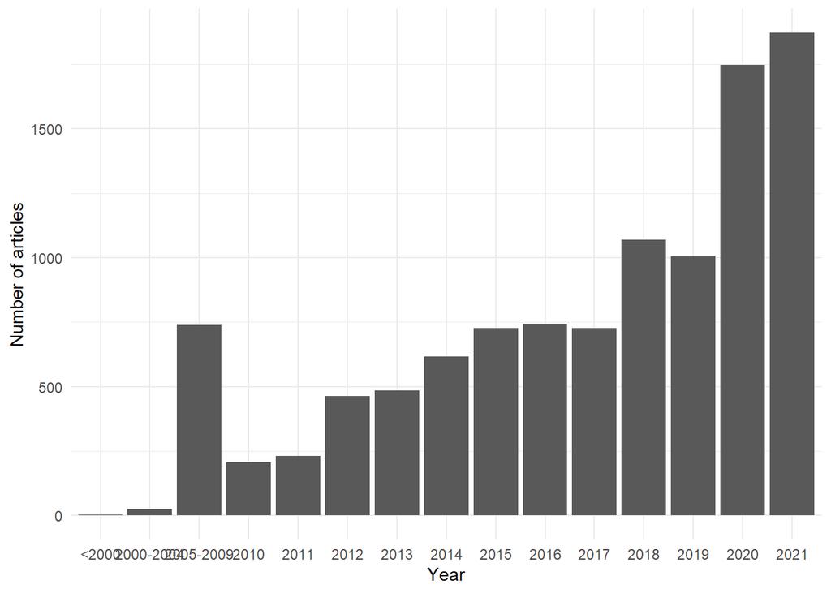

```r
by_year <-
  opendata %>%
  mutate(pubYear_modified = forcats::fct_collapse(pubYear_modified,
                                                  "<2005" = c("< 2000",
                                                              "2000 - 2004")))  %>%
  mutate(pubYear_modified - fct_drop(pubYear_modified)) %>%
count(pubYear_modified) %>%
  complete(pubYear_modified, fill = list(n = 0)) %>%
  group_by(pubYear_modified) %>%
  ungroup()

sf1 <-
       by_year %>%
        ggplot() +
        aes(x = pubYear_modified,
            y = n) +
        geom_col() +
        labs(y = "Number of articles",
             x = "Year") +
        theme(panel.grid.minor = element_blank(),
              axis.text.x = element_text(angle = 45, vjust = 0.9, hjust=1)
              ) +
  theme_minimal()
sf1
```

```r
ggsave(here("figure", "Figure_sf1_alternate.tiff") ,
            width = 9, height = 5, units = "in", dpi = 700,compression = "lzw")
```

Statistical significance tests over years

```r
fisher.test(opendata$is_coi_pred, opendata$pubYear_modified,simulate.p.value = T)
```

```
##
##  Fisher's Exact Test for Count Data with simulated p-value (based on
##  2000 replicates)
##
## data:  opendata$is_coi_pred and opendata$pubYear_modified
## p-value = 0.0004998
## alternative hypothesis: two.sided
```

```r
fisher.test(opendata$is_fund_pred, opendata$pubYear_modified,simulate.p.value = T)
```

```
##
##  Fisher's Exact Test for Count Data with simulated p-value (based on
##  2000 replicates)
##
## data:  opendata$is_fund_pred and opendata$pubYear_modified
## p-value = 0.0004998
## alternative hypothesis: two.sided
```

```r
fisher.test(opendata$is_register_pred, opendata$pubYear_modified,simulate.p.value = T)
```

```
##
##  Fisher's Exact Test for Count Data with simulated p-value (based on
##  2000 replicates)
##
## data:  opendata$is_register_pred and opendata$pubYear_modified
## p-value = 0.0004998
## alternative hypothesis: two.sided
```

```r
fisher.test(opendata$is_open_data, opendata$pubYear_modified,simulate.p.value = T)
```

```
##
##  Fisher's Exact Test for Count Data with simulated p-value (based on
##  2000 replicates)
##
## data:  opendata$is_open_data and opendata$pubYear_modified
## p-value = 0.0004998
## alternative hypothesis: two.sided
```

```r
fisher.test(opendata$is_open_code, opendata$pubYear_modified,simulate.p.value = T)
```

```
##
##  Fisher's Exact Test for Count Data with simulated p-value (based on
##  2000 replicates)
##
## data:  opendata$is_open_code and opendata$pubYear_modified
## p-value = 0.8631
## alternative hypothesis: two.sided
```

# Validation

Comparison of algorithm-based and manual study type categorization. Random sample of 100 articles.

```r
papertype_sample_valid <- read.csv2(here("data", "papertype_sample_valid.csv"))
table(papertype_sample_valid$predicted,papertype_sample_valid$true)
```

```
##
##                  interventional laboratory observational other review
##   interventional             15          4             2     1      0
##   laboratory                  1         16             0     0      0
##   observational               1          3            31     1      0
##   other                       2          4             1     7      0
##   review                      0          0             2     0      9
```

Validation sample of transparency practice identification in 49 random articles. Data preparation.

```r
validation_data = read.csv(here("data","dental_transparency_article_sample.csv"))
validation_data = validation_data  %>% mutate(true_coi =
case_when( is_coi_pred ==FALSE & disc_coi ==TRUE ~ TRUE,
is_coi_pred ==TRUE & disc_coi ==TRUE ~ FALSE,
is_coi_pred ==TRUE & disc_coi ==FALSE ~ TRUE,
is_coi_pred ==FALSE & disc_coi ==FALSE ~ FALSE))
validation_data = validation_data  %>% mutate(true_fund =
case_when( is_fund_pred ==FALSE & disc_fund ==TRUE ~ TRUE,
is_fund_pred ==TRUE & disc_fund ==TRUE ~ FALSE,
is_fund_pred ==TRUE & disc_fund ==FALSE ~ TRUE,
is_fund_pred ==FALSE & disc_fund ==FALSE ~ FALSE))
validation_data = validation_data   %>% mutate(true_reg =
case_when( is_register_pred ==FALSE & disc_register ==TRUE ~ TRUE,
is_register_pred ==TRUE & disc_register ==TRUE ~ FALSE,
is_register_pred ==TRUE & disc_register ==FALSE ~ TRUE,
is_register_pred ==FALSE & disc_register ==FALSE ~ FALSE))
validation_data = validation_data  %>% mutate(true_data =
case_when( is_open_data ==FALSE & disc_data ==TRUE ~ TRUE,
is_open_data ==TRUE & disc_data ==TRUE ~ FALSE,
is_open_data ==TRUE & disc_data ==FALSE ~ TRUE,
is_open_data ==FALSE & disc_data ==FALSE ~ FALSE))
validation_data = validation_data   %>% mutate(true_code =
case_when( is_open_code ==FALSE & disc_code ==TRUE ~ TRUE,
is_open_code ==TRUE & disc_code ==TRUE ~ FALSE,
is_open_code ==TRUE & disc_code ==FALSE ~ TRUE,
is_open_code ==FALSE & disc_code ==FALSE ~ FALSE))
```

Confusion matrix.

```r
validation_data %>% select(is_coi_pred,true_coi) %>% table()
```

```
##            true_coi
## is_coi_pred FALSE TRUE
##       FALSE     8    1
##       TRUE      3   37
```

```r
validation_data %>% select(is_fund_pred,true_fund) %>% table()
```

```
##             true_fund
## is_fund_pred FALSE TRUE
##        FALSE    24    0
##        TRUE      1   24
```

```r
validation_data %>% select(is_register_pred,true_reg) %>% table()
```

```
##                 true_reg
## is_register_pred FALSE TRUE
##            FALSE    43    1
##            TRUE      1    4
```

```r
validation_data %>% select(is_open_data,true_data) %>% table()
```

```
##             true_data
## is_open_data FALSE TRUE
##        FALSE    47    1
##        TRUE      1    0
```

```r
validation_data %>% select(is_open_code,true_code) %>% table()
```

```
##             true_code
## is_open_code FALSE
##        FALSE    49
```

Calculation of specificity and sensitivity.

```r
validation_data %>% select(is_coi_pred,true_coi) %>% table() %>% sensitivity()
```

```
## [1] 0.7272727
```

```r
validation_data %>% select(is_coi_pred,true_coi) %>% table() %>% specificity()
```

```
## [1] 0.9736842
```

```r
validation_data %>% select(is_fund_pred,true_fund) %>% table() %>% sensitivity()
```

```
## [1] 0.96
```

```r
validation_data %>% select(is_fund_pred,true_fund) %>% table() %>% specificity()
```

```
## [1] 1
```

```r
validation_data %>% select(is_register_pred,true_reg) %>% table() %>% sensitivity()
```

```
## [1] 0.9772727
```

```r
validation_data %>% select(is_register_pred,true_reg) %>% table() %>% specificity()
```

```
## [1] 0.8
```

```r
validation_data %>% select(is_open_data,true_data) %>% table() %>% sensitivity()
```

```
## [1] 0.9791667
```

```r
validation_data %>% select(is_open_data,true_data) %>% table() %>% specificity()
```

```
## [1] 0
```

```r
validation_data %>% select(is_open_code,true_code) %>% table() %>% sensitivity()
```

```
## [1] 1
```

```r
validation_data %>% select(is_open_code,true_code) %>% table() %>% specificity()
```

```
## [1] NA
```